# Assigning ASVs with DADA2 - Anglerfish

Griffin Patel

April 06, 2026

# Goals

## Input

1. Filtered fastq files generated from `01_QualityTrimmingAnglerfish.Rmd`.
2. Sample name vector.

## Output

# Set up the Environment

## Set Seed & Threads

```r
# Set the seed for reproducibility
set.seed(238428)

# Set the number of threads
n_threads <- 20
```

## Timing of this script

```r
# What time did we start running this script?
start_time <- Sys.time()
```

## Load Packages

```r
# Install packages if needed
if (!requireNamespace("BiocManager", quietly = TRUE)) {
  install.packages("BiocManager")
}

if (!requireNamespace("dada2", quietly = TRUE)) {
  BiocManager::install("dada2", ask = FALSE, update = FALSE)
}

if (!requireNamespace("phyloseq", quietly = TRUE)) {
  BiocManager::install("phyloseq", ask = FALSE, update = FALSE)
}

if (!requireNamespace("tidyverse", quietly = TRUE)) {
  install.packages("tidyverse")
}

if (!requireNamespace("devtools", quietly = TRUE)) {
  install.packages("devtools")
}

if (!requireNamespace("patchwork", quietly = TRUE)) {
  install.packages("patchwork")
}

if (!requireNamespace("DT", quietly = TRUE)) {
  install.packages("DT")
}

library(tidyverse)
library(devtools)
library(dada2)
library(phyloseq)
library(patchwork)
library(DT)
```

## Load Filtered Fastq Files

```r
# Place filtered seq files into a variable
filtered_fastqs_path <- "/local/workdir/glp56/Anglerfish_16S/data/01_Quality_Trimming_Lecture/filtered_fastqs"

# Intuition check:
filtered_fastqs_path
```

```
## [1] "/local/workdir/glp56/Anglerfish_16S/data/01_Quality_Trimming_Lecture/filtered_fastqs"
```

```r
# Create forward vector
filtered_forward_reads <-
  sort(list.files(filtered_fastqs_path,
                  pattern = "R1_filtered.fastq.gz$",
                  full.names = TRUE))

# Check
filtered_forward_reads[1:5]
```

```
## [1] "/local/workdir/glp56/Anglerfish_16S/data/01_Quality_Trimming_Lecture/filtered_fastqs/SRR8438042_R1_filtered.fastq.gz"
## [2] "/local/workdir/glp56/Anglerfish_16S/data/01_Quality_Trimming_Lecture/filtered_fastqs/SRR8438043_R1_filtered.fastq.gz"
## [3] "/local/workdir/glp56/Anglerfish_16S/data/01_Quality_Trimming_Lecture/filtered_fastqs/SRR8438044_R1_filtered.fastq.gz"
## [4] "/local/workdir/glp56/Anglerfish_16S/data/01_Quality_Trimming_Lecture/filtered_fastqs/SRR8438045_R1_filtered.fastq.gz"
## [5] "/local/workdir/glp56/Anglerfish_16S/data/01_Quality_Trimming_Lecture/filtered_fastqs/SRR8438046_R1_filtered.fastq.gz"
```

```r
# Create reverse vector
filtered_reverse_reads <-
  sort(list.files(filtered_fastqs_path,
                  pattern = "R2_filtered.fastq.gz$",
                  full.names = TRUE))

# Check
filtered_reverse_reads[1:5]
```

```
## [1] "/local/workdir/glp56/Anglerfish_16S/data/01_Quality_Trimming_Lecture/filtered_fastqs/SRR8438042_R2_filtered.fastq.gz"
## [2] "/local/workdir/glp56/Anglerfish_16S/data/01_Quality_Trimming_Lecture/filtered_fastqs/SRR8438043_R2_filtered.fastq.gz"
## [3] "/local/workdir/glp56/Anglerfish_16S/data/01_Quality_Trimming_Lecture/filtered_fastqs/SRR8438044_R2_filtered.fastq.gz"
## [4] "/local/workdir/glp56/Anglerfish_16S/data/01_Quality_Trimming_Lecture/filtered_fastqs/SRR8438045_R2_filtered.fastq.gz"
## [5] "/local/workdir/glp56/Anglerfish_16S/data/01_Quality_Trimming_Lecture/filtered_fastqs/SRR8438046_R2_filtered.fastq.gz"
```

```r
# Intuition checks
length(filtered_forward_reads)
```

```
## [1] 117
```

```r
length(filtered_reverse_reads)
```

```
## [1] 117
```

```r
stopifnot(length(filtered_forward_reads) > 0)
stopifnot(length(filtered_forward_reads) == length(filtered_reverse_reads))
```

## Sample Names

```r
# Create vector of sample names from the filenames
sample_names <- sapply(strsplit(basename(filtered_forward_reads), "_"), `[`, 1)

# Intuition check
head(sample_names)
```

```
## [1] "SRR8438042" "SRR8438043" "SRR8438044" "SRR8438045" "SRR8438046"
## [6] "SRR8438047"
```

```r
# Confirm reverse filenames match
stopifnot(
  identical(
    sample_names,
    sapply(strsplit(basename(filtered_reverse_reads), "_"), `[`, 1)
  )
)
```

# Error Modelling

## Learn the Errors

### MiSeq Runs: 40 Phred Scores

```r
# Forward reads
error_forward_reads <-
  learnErrors(filtered_forward_reads, multithread = n_threads)
```

```
## 111527680 total bases in 506944 reads from 10 samples will be used for learning the error rates.
```

```r
# Forward error plot
forward_error_plot <-
  plotErrors(error_forward_reads, nominalQ = TRUE) +
  labs(title = "Forward Reads: Error Model")

# Reverse reads
error_reverse_reads <-
  learnErrors(filtered_reverse_reads, multithread = n_threads)
```

```
## 101388800 total bases in 506944 reads from 10 samples will be used for learning the error rates.
```

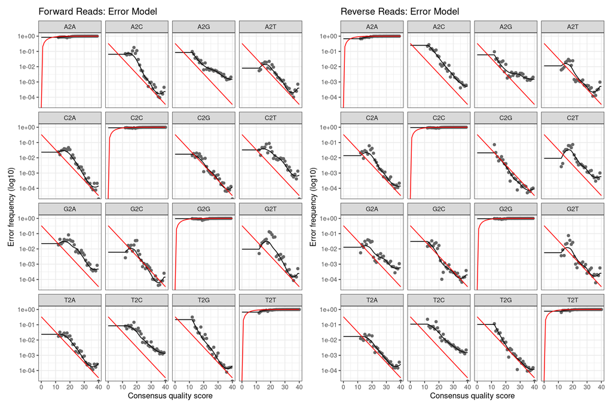

```r
# Reverse error plot
reverse_error_plot <-
  plotErrors(error_reverse_reads, nominalQ = TRUE) +
  labs(title = "Reverse Reads: Error Model")

# Look at the plots together
forward_error_plot + reverse_error_plot
```

# Infer ASVs

**An important note:** What makes DADA2 so nice is that it infers ASVs separately on the forward and the reverse reads and then merges them afterwards. This is quite a different approach from how OTUs are identified in Mothur and also from UCHIME, oligotyping, and other OTU, MED, and ASV approaches.

```r
# Infer ASVs on the forward sequences
dada_forward <-
  dada(filtered_forward_reads,
       err = error_forward_reads,
       multithread = n_threads)
```

```
## Sample 1 - 47848 reads in 16721 unique sequences.
## Sample 2 - 4264 reads in 1292 unique sequences.
## Sample 3 - 95125 reads in 22677 unique sequences.
## Sample 4 - 20997 reads in 5963 unique sequences.
## Sample 5 - 15430 reads in 4058 unique sequences.
## Sample 6 - 26554 reads in 8587 unique sequences.
## Sample 7 - 77964 reads in 17525 unique sequences.
## Sample 8 - 109405 reads in 32367 unique sequences.
## Sample 9 - 26941 reads in 3662 unique sequences.
## Sample 10 - 82416 reads in 15206 unique sequences.
## Sample 11 - 116132 reads in 38483 unique sequences.
## Sample 12 - 25488 reads in 6887 unique sequences.
## Sample 13 - 1236 reads in 487 unique sequences.
## Sample 14 - 106988 reads in 30907 unique sequences.
## Sample 15 - 40092 reads in 13138 unique sequences.
## Sample 16 - 76882 reads in 20707 unique sequences.
## Sample 17 - 65690 reads in 17464 unique sequences.
## Sample 18 - 40806 reads in 14077 unique sequences.
## Sample 19 - 6618 reads in 1930 unique sequences.
## Sample 20 - 59970 reads in 19832 unique sequences.
## Sample 21 - 20847 reads in 6157 unique sequences.
## Sample 22 - 67102 reads in 15155 unique sequences.
## Sample 23 - 38743 reads in 8824 unique sequences.
## Sample 24 - 90565 reads in 17434 unique sequences.
## Sample 25 - 102299 reads in 13874 unique sequences.
## Sample 26 - 24905 reads in 6507 unique sequences.
## Sample 27 - 6905 reads in 2390 unique sequences.
## Sample 28 - 24408 reads in 3656 unique sequences.
## Sample 29 - 68313 reads in 14749 unique sequences.
## Sample 30 - 82355 reads in 18684 unique sequences.
## Sample 31 - 113930 reads in 23578 unique sequences.
## Sample 32 - 73034 reads in 13005 unique sequences.
## Sample 33 - 86504 reads in 15698 unique sequences.
## Sample 34 - 4983 reads in 1711 unique sequences.
## Sample 35 - 54640 reads in 11207 unique sequences.
## Sample 36 - 49738 reads in 11778 unique sequences.
## Sample 37 - 63343 reads in 17553 unique sequences.
## Sample 38 - 80028 reads in 14935 unique sequences.
## Sample 39 - 87220 reads in 17429 unique sequences.
## Sample 40 - 93612 reads in 21298 unique sequences.
```

[output cut: 62 more lines]

```
## Sample 103 - 24971 reads in 10526 unique sequences.
## Sample 104 - 83921 reads in 15889 unique sequences.
## Sample 105 - 76408 reads in 14181 unique sequences.
## Sample 106 - 49300 reads in 8714 unique sequences.
## Sample 107 - 72950 reads in 10972 unique sequences.
## Sample 108 - 70012 reads in 14013 unique sequences.
## Sample 109 - 52562 reads in 12775 unique sequences.
## Sample 110 - 18746 reads in 5661 unique sequences.
## Sample 111 - 9031 reads in 3088 unique sequences.
## Sample 112 - 12737 reads in 4185 unique sequences.
## Sample 113 - 151010 reads in 32209 unique sequences.
## Sample 114 - 63702 reads in 18229 unique sequences.
## Sample 115 - 90931 reads in 21423 unique sequences.
## Sample 116 - 26886 reads in 9301 unique sequences.
## Sample 117 - 76398 reads in 19366 unique sequences.
```

```r
# Take a look at the data
# What type of data structure is it?
typeof(dada_forward) # It's a list
```

```
## [1] "list"
```

```r
length(dada_forward) # How big is it? One per sample!
```

```
## [1] 117
```

```r
# What does it look like for each sample?
dada_forward[[1]]
```

```
## dada-class: object describing DADA2 denoising results
## 162 sequence variants were inferred from 16721 input unique sequences.
## Key parameters: OMEGA_A = 1e-40, OMEGA_C = 1e-40, BAND_SIZE = 16
```

```r
# Reverse ASVs
dada_reverse <-
  dada(filtered_reverse_reads,
       err = error_reverse_reads,
       multithread = n_threads)
```

```
## Sample 1 - 47848 reads in 23713 unique sequences.
## Sample 2 - 4264 reads in 1756 unique sequences.
## Sample 3 - 95125 reads in 31289 unique sequences.
## Sample 4 - 20997 reads in 10934 unique sequences.
## Sample 5 - 15430 reads in 6589 unique sequences.
## Sample 6 - 26554 reads in 10877 unique sequences.
## Sample 7 - 77964 reads in 20113 unique sequences.
## Sample 8 - 109405 reads in 40423 unique sequences.
## Sample 9 - 26941 reads in 6374 unique sequences.
## Sample 10 - 82416 reads in 24874 unique sequences.
## Sample 11 - 116132 reads in 47092 unique sequences.
## Sample 12 - 25488 reads in 10088 unique sequences.
## Sample 13 - 1236 reads in 757 unique sequences.
## Sample 14 - 106988 reads in 41395 unique sequences.
## Sample 15 - 40092 reads in 16201 unique sequences.
## Sample 16 - 76882 reads in 24936 unique sequences.
## Sample 17 - 65690 reads in 25494 unique sequences.
## Sample 18 - 40806 reads in 16621 unique sequences.
## Sample 19 - 6618 reads in 3387 unique sequences.
## Sample 20 - 59970 reads in 22657 unique sequences.
## Sample 21 - 20847 reads in 11670 unique sequences.
## Sample 22 - 67102 reads in 21150 unique sequences.
## Sample 23 - 38743 reads in 15782 unique sequences.
## Sample 24 - 90565 reads in 26513 unique sequences.
## Sample 25 - 102299 reads in 35933 unique sequences.
## Sample 26 - 24905 reads in 10603 unique sequences.
## Sample 27 - 6905 reads in 3922 unique sequences.
## Sample 28 - 24408 reads in 5342 unique sequences.
## Sample 29 - 68313 reads in 20880 unique sequences.
## Sample 30 - 82355 reads in 30899 unique sequences.
## Sample 31 - 113930 reads in 32718 unique sequences.
## Sample 32 - 73034 reads in 26053 unique sequences.
## Sample 33 - 86504 reads in 24748 unique sequences.
## Sample 34 - 4983 reads in 2946 unique sequences.
## Sample 35 - 54640 reads in 17619 unique sequences.
## Sample 36 - 49738 reads in 19458 unique sequences.
## Sample 37 - 63343 reads in 26584 unique sequences.
## Sample 38 - 80028 reads in 22454 unique sequences.
## Sample 39 - 87220 reads in 25250 unique sequences.
## Sample 40 - 93612 reads in 29621 unique sequences.
```

[output cut: 62 more lines]

```
## Sample 103 - 24971 reads in 14478 unique sequences.
## Sample 104 - 83921 reads in 24977 unique sequences.
## Sample 105 - 76408 reads in 25041 unique sequences.
## Sample 106 - 49300 reads in 17491 unique sequences.
## Sample 107 - 72950 reads in 23630 unique sequences.
## Sample 108 - 70012 reads in 20945 unique sequences.
## Sample 109 - 52562 reads in 18573 unique sequences.
## Sample 110 - 18746 reads in 8019 unique sequences.
## Sample 111 - 9031 reads in 4264 unique sequences.
## Sample 112 - 12737 reads in 6380 unique sequences.
## Sample 113 - 151010 reads in 33053 unique sequences.
## Sample 114 - 63702 reads in 26847 unique sequences.
## Sample 115 - 90931 reads in 30016 unique sequences.
## Sample 116 - 26886 reads in 11293 unique sequences.
## Sample 117 - 76398 reads in 29789 unique sequences.
```

```r
# Check data
dada_reverse[[1]]
```

```
## dada-class: object describing DADA2 denoising results
## 132 sequence variants were inferred from 23713 input unique sequences.
## Key parameters: OMEGA_A = 1e-40, OMEGA_C = 1e-40, BAND_SIZE = 16
```

# Merge Forward and Reverse ASVs

Now, that we have identified our ASVs separately on both the forward and the reverse reads, let’s **merge** them together into contiguous (*aka* “contigs”) ASVs.

```r
merged_ASVs <-
  mergePairs(dada_forward, filtered_forward_reads,
             dada_reverse, filtered_reverse_reads,
             verbose = TRUE)
```

```
## 46569 paired-reads (in 169 unique pairings) successfully merged out of 47432 (in 338 pairings) input.
```

```
## 4078 paired-reads (in 17 unique pairings) successfully merged out of 4196 (in 40 pairings) input.
```

```
## 92568 paired-reads (in 156 unique pairings) successfully merged out of 94839 (in 384 pairings) input.
```

```
## 19927 paired-reads (in 93 unique pairings) successfully merged out of 20889 (in 142 pairings) input.
```

```
## 15079 paired-reads (in 76 unique pairings) successfully merged out of 15337 (in 103 pairings) input.
```

```
## 26122 paired-reads (in 67 unique pairings) successfully merged out of 26380 (in 155 pairings) input.
```

```
## 77302 paired-reads (in 48 unique pairings) successfully merged out of 77720 (in 167 pairings) input.
```

```
## 107058 paired-reads (in 132 unique pairings) successfully merged out of 108681 (in 580 pairings) input.
```

```
## 26212 paired-reads (in 170 unique pairings) successfully merged out of 26630 (in 229 pairings) input.
```

```
## 79984 paired-reads (in 24 unique pairings) successfully merged out of 82068 (in 168 pairings) input.
```

```
## 109007 paired-reads (in 159 unique pairings) successfully merged out of 114594 (in 1458 pairings) input.
```

```
## 22409 paired-reads (in 485 unique pairings) successfully merged out of 24854 (in 649 pairings) input.
```

```
## 1167 paired-reads (in 40 unique pairings) successfully merged out of 1186 (in 43 pairings) input.
```

```
## 101942 paired-reads (in 143 unique pairings) successfully merged out of 106327 (in 963 pairings) input.
```

```
## 39546 paired-reads (in 66 unique pairings) successfully merged out of 40027 (in 187 pairings) input.
```

```
## 75581 paired-reads (in 156 unique pairings) successfully merged out of 76542 (in 398 pairings) input.
```

```
## 62993 paired-reads (in 220 unique pairings) successfully merged out of 65303 (in 455 pairings) input.
```

```
## 39869 paired-reads (in 99 unique pairings) successfully merged out of 40617 (in 295 pairings) input.
```

```
## 6147 paired-reads (in 44 unique pairings) successfully merged out of 6538 (in 63 pairings) input.
```

```
## 58151 paired-reads (in 98 unique pairings) successfully merged out of 59560 (in 447 pairings) input.
```

```
## 19829 paired-reads (in 201 unique pairings) successfully merged out of 20716 (in 237 pairings) input.
```

```
## 65827 paired-reads (in 217 unique pairings) successfully merged out of 66799 (in 347 pairings) input.
```

```
## 37661 paired-reads (in 152 unique pairings) successfully merged out of 38536 (in 202 pairings) input.
```

```
## 89924 paired-reads (in 80 unique pairings) successfully merged out of 90424 (in 160 pairings) input.
```

```
## 85286 paired-reads (in 24 unique pairings) successfully merged out of 101785 (in 100 pairings) input.
```

```
## 23701 paired-reads (in 117 unique pairings) successfully merged out of 24767 (in 151 pairings) input.
```

```
## 6271 paired-reads (in 108 unique pairings) successfully merged out of 6753 (in 133 pairings) input.
```

```
## 23757 paired-reads (in 108 unique pairings) successfully merged out of 24028 (in 169 pairings) input.
```

```
## 67196 paired-reads (in 85 unique pairings) successfully merged out of 67957 (in 203 pairings) input.
```

```
## 80558 paired-reads (in 101 unique pairings) successfully merged out of 82004 (in 365 pairings) input.
```

```
## 111567 paired-reads (in 79 unique pairings) successfully merged out of 113582 (in 449 pairings) input.
```

```
## 71731 paired-reads (in 177 unique pairings) successfully merged out of 72752 (in 282 pairings) input.
```

```
## 84362 paired-reads (in 20 unique pairings) successfully merged out of 86254 (in 43 pairings) input.
```

```
## 4648 paired-reads (in 61 unique pairings) successfully merged out of 4926 (in 81 pairings) input.
```

```
## 53803 paired-reads (in 102 unique pairings) successfully merged out of 54505 (in 153 pairings) input.
```

```
## 46682 paired-reads (in 133 unique pairings) successfully merged out of 49351 (in 216 pairings) input.
```

```
## 61920 paired-reads (in 197 unique pairings) successfully merged out of 63034 (in 355 pairings) input.
```

```
## 78765 paired-reads (in 100 unique pairings) successfully merged out of 79763 (in 203 pairings) input.
```

```
## 86040 paired-reads (in 110 unique pairings) successfully merged out of 86896 (in 236 pairings) input.
```

```
## 91646 paired-reads (in 177 unique pairings) successfully merged out of 93060 (in 352 pairings) input.
```

```
## 99361 paired-reads (in 291 unique pairings) successfully merged out of 102554 (in 446 pairings) input.
```

```
## 102860 paired-reads (in 75 unique pairings) successfully merged out of 104464 (in 164 pairings) input.
```

```
## 19707 paired-reads (in 126 unique pairings) successfully merged out of 20072 (in 152 pairings) input.
```

```
## 17966 paired-reads (in 130 unique pairings) successfully merged out of 19565 (in 169 pairings) input.
```

```
## 20615 paired-reads (in 142 unique pairings) successfully merged out of 21075 (in 181 pairings) input.
```

```
## 72303 paired-reads (in 114 unique pairings) successfully merged out of 76362 (in 172 pairings) input.
```

```
## 84387 paired-reads (in 57 unique pairings) successfully merged out of 85204 (in 182 pairings) input.
```

```
## 63969 paired-reads (in 269 unique pairings) successfully merged out of 65997 (in 433 pairings) input.
```

```
## 66583 paired-reads (in 78 unique pairings) successfully merged out of 67446 (in 200 pairings) input.
```

```
## 70737 paired-reads (in 56 unique pairings) successfully merged out of 71668 (in 246 pairings) input.
```

```
## 67153 paired-reads (in 241 unique pairings) successfully merged out of 67882 (in 351 pairings) input.
```

```
## 8199 paired-reads (in 92 unique pairings) successfully merged out of 8404 (in 119 pairings) input.
```

```
## 73631 paired-reads (in 19 unique pairings) successfully merged out of 73866 (in 48 pairings) input.
```

```
## 74466 paired-reads (in 99 unique pairings) successfully merged out of 75811 (in 311 pairings) input.
```

```
## 26667 paired-reads (in 158 unique pairings) successfully merged out of 27082 (in 220 pairings) input.
```

```
## 19606 paired-reads (in 160 unique pairings) successfully merged out of 20226 (in 200 pairings) input.
```

```
## 56277 paired-reads (in 145 unique pairings) successfully merged out of 57018 (in 271 pairings) input.
```

```
## 105252 paired-reads (in 39 unique pairings) successfully merged out of 106412 (in 156 pairings) input.
```

```
## 91021 paired-reads (in 263 unique pairings) successfully merged out of 92568 (in 417 pairings) input.
```

```
## 87331 paired-reads (in 252 unique pairings) successfully merged out of 88783 (in 470 pairings) input.
```

```
## 76875 paired-reads (in 198 unique pairings) successfully merged out of 78393 (in 370 pairings) input.
```

```
## 78285 paired-reads (in 185 unique pairings) successfully merged out of 79649 (in 393 pairings) input.
```

```
## 15879 paired-reads (in 163 unique pairings) successfully merged out of 16711 (in 221 pairings) input.
```

```
## 15542 paired-reads (in 149 unique pairings) successfully merged out of 16610 (in 220 pairings) input.
```

```
## 95582 paired-reads (in 40 unique pairings) successfully merged out of 95951 (in 104 pairings) input.
```

```
## 68707 paired-reads (in 177 unique pairings) successfully merged out of 70060 (in 272 pairings) input.
```

```
## 52283 paired-reads (in 366 unique pairings) successfully merged out of 54181 (in 536 pairings) input.
```

```
## 73577 paired-reads (in 242 unique pairings) successfully merged out of 74796 (in 368 pairings) input.
```

```
## 49740 paired-reads (in 211 unique pairings) successfully merged out of 50237 (in 307 pairings) input.
```

```
## 63800 paired-reads (in 65 unique pairings) successfully merged out of 64812 (in 165 pairings) input.
```

```
## 35051 paired-reads (in 185 unique pairings) successfully merged out of 35937 (in 310 pairings) input.
```

```
## 39867 paired-reads (in 178 unique pairings) successfully merged out of 40589 (in 249 pairings) input.
```

```
## 74731 paired-reads (in 315 unique pairings) successfully merged out of 76337 (in 474 pairings) input.
```

```
## 53132 paired-reads (in 262 unique pairings) successfully merged out of 54499 (in 357 pairings) input.
```

```
## 38480 paired-reads (in 191 unique pairings) successfully merged out of 39303 (in 262 pairings) input.
```

```
## 17360 paired-reads (in 150 unique pairings) successfully merged out of 18388 (in 212 pairings) input.
```

```
## 11702 paired-reads (in 39 unique pairings) successfully merged out of 11924 (in 73 pairings) input.
```

```
## 26328 paired-reads (in 101 unique pairings) successfully merged out of 26534 (in 164 pairings) input.
```

```
## 25569 paired-reads (in 59 unique pairings) successfully merged out of 25684 (in 94 pairings) input.
```

```
## 85900 paired-reads (in 77 unique pairings) successfully merged out of 86253 (in 190 pairings) input.
```

```
## 17506 paired-reads (in 253 unique pairings) successfully merged out of 17897 (in 321 pairings) input.
```

```
## 85909 paired-reads (in 104 unique pairings) successfully merged out of 88831 (in 564 pairings) input.
```

```
## 77842 paired-reads (in 102 unique pairings) successfully merged out of 79248 (in 424 pairings) input.
```

```
## 340943 paired-reads (in 248 unique pairings) successfully merged out of 352950 (in 1694 pairings) input.
```

```
## 65261 paired-reads (in 111 unique pairings) successfully merged out of 65785 (in 238 pairings) input.
```

```
## 73189 paired-reads (in 110 unique pairings) successfully merged out of 73716 (in 240 pairings) input.
```

```
## 173 paired-reads (in 26 unique pairings) successfully merged out of 201 (in 33 pairings) input.
```

```
## 11975 paired-reads (in 75 unique pairings) successfully merged out of 13677 (in 93 pairings) input.
```

```
## 66509 paired-reads (in 260 unique pairings) successfully merged out of 76253 (in 367 pairings) input.
```

```
## 38449 paired-reads (in 79 unique pairings) successfully merged out of 39603 (in 178 pairings) input.
```

```
## 87652 paired-reads (in 71 unique pairings) successfully merged out of 89262 (in 213 pairings) input.
```

```
## 22788 paired-reads (in 79 unique pairings) successfully merged out of 23212 (in 170 pairings) input.
```

```
## 10224 paired-reads (in 34 unique pairings) successfully merged out of 10415 (in 62 pairings) input.
```

```
## 7626 paired-reads (in 35 unique pairings) successfully merged out of 7683 (in 59 pairings) input.
```

```
## 9297 paired-reads (in 43 unique pairings) successfully merged out of 9589 (in 58 pairings) input.
```

```
## 17230 paired-reads (in 47 unique pairings) successfully merged out of 17589 (in 81 pairings) input.
```

```
## 57486 paired-reads (in 96 unique pairings) successfully merged out of 59386 (in 338 pairings) input.
```

```
## 21590 paired-reads (in 772 unique pairings) successfully merged out of 23883 (in 1267 pairings) input.
```

```
## 28210 paired-reads (in 65 unique pairings) successfully merged out of 28474 (in 105 pairings) input.
```

```
## 98000 paired-reads (in 32 unique pairings) successfully merged out of 98167 (in 55 pairings) input.
```

```
## 19251 paired-reads (in 918 unique pairings) successfully merged out of 21607 (in 1427 pairings) input.
```

```
## 19230 paired-reads (in 1186 unique pairings) successfully merged out of 22137 (in 1718 pairings) input.
```

```
## 18082 paired-reads (in 1312 unique pairings) successfully merged out of 21703 (in 1985 pairings) input.
```

```
## 82562 paired-reads (in 117 unique pairings) successfully merged out of 83614 (in 274 pairings) input.
```

```
## 75193 paired-reads (in 105 unique pairings) successfully merged out of 75956 (in 233 pairings) input.
```

```
## 45321 paired-reads (in 88 unique pairings) successfully merged out of 49129 (in 149 pairings) input.
```

```
## 64581 paired-reads (in 63 unique pairings) successfully merged out of 72647 (in 186 pairings) input.
```

```
## 67742 paired-reads (in 79 unique pairings) successfully merged out of 69699 (in 240 pairings) input.
```

```
## 50439 paired-reads (in 128 unique pairings) successfully merged out of 52281 (in 351 pairings) input.
```

```
## 17804 paired-reads (in 53 unique pairings) successfully merged out of 18630 (in 149 pairings) input.
```

```
## 8809 paired-reads (in 47 unique pairings) successfully merged out of 8985 (in 75 pairings) input.
```

```
## 12498 paired-reads (in 49 unique pairings) successfully merged out of 12674 (in 63 pairings) input.
```

```
## 147425 paired-reads (in 77 unique pairings) successfully merged out of 150632 (in 319 pairings) input.
```

```
## 61473 paired-reads (in 155 unique pairings) successfully merged out of 63444 (in 278 pairings) input.
```

```
## 88415 paired-reads (in 143 unique pairings) successfully merged out of 90656 (in 396 pairings) input.
```

```
## 26238 paired-reads (in 56 unique pairings) successfully merged out of 26694 (in 190 pairings) input.
```

```
## 72380 paired-reads (in 96 unique pairings) successfully merged out of 75969 (in 316 pairings) input.
```

```r
# Evaluate the data output
typeof(merged_ASVs) # A list
```

```
## [1] "list"
```

```r
length(merged_ASVs) # Length of the number of samples!
```

```
## [1] 117
```

```r
head(names(merged_ASVs)) # Here, we can access our current sample names
```

```
## [1] "SRR8438042_R1_filtered.fastq.gz" "SRR8438043_R1_filtered.fastq.gz"
## [3] "SRR8438044_R1_filtered.fastq.gz" "SRR8438045_R1_filtered.fastq.gz"
## [5] "SRR8438046_R1_filtered.fastq.gz" "SRR8438047_R1_filtered.fastq.gz"
```

```r
# Inspect further for each sample
glimpse(merged_ASVs[[1]])
```

```
## Rows: 169
## Columns: 9
## $ sequence  <chr> "TACGAAGGGGGCTAGCGTTGCTCGGAATCACTGGGCGTAAAGGGTGCGTAGGCGGGTCT…
## $ abundance <int> 11977, 3994, 3152, 2841, 2058, 1391, 955, 789, 666, 644, 635…
## $ forward   <int> 1, 2, 4, 3, 5, 6, 7, 8, 12, 10, 9, 11, 17, 15, 13, 14, 16, 1…
## $ reverse   <int> 1, 2, 3, 4, 5, 6, 7, 8, 15, 10, 13, 12, 14, 11, 18, 17, 19, …
## $ nmatch    <int> 167, 167, 167, 167, 167, 167, 167, 167, 167, 167, 167, 167, …
## $ nmismatch <int> 0, 0, 0, 0, 0, 0, 0, 0, 0, 0, 0, 0, 0, 0, 0, 0, 0, 0, 0, 0, …
## $ nindel    <int> 0, 0, 0, 0, 0, 0, 0, 0, 0, 0, 0, 0, 0, 0, 0, 0, 0, 0, 0, 0, …
## $ prefer    <dbl> 1, 1, 1, 1, 1, 1, 1, 1, 1, 1, 1, 1, 1, 1, 1, 1, 1, 1, 1, 1, …
## $ accept    <lgl> TRUE, TRUE, TRUE, TRUE, TRUE, TRUE, TRUE, TRUE, TRUE, TRUE, …
```

# Create Raw ASV Count Table

```r
# Raw ASV
raw_ASV_table <- makeSequenceTable(merged_ASVs)

# Intuition Check: Type and dimensions of the data
dim(raw_ASV_table)
```

```
## [1]   117 11053
```

```r
typeof(raw_ASV_table)
```

```
## [1] "integer"
```

```r
class(raw_ASV_table)
```

```
## [1] "matrix" "array"
```

```r
# Write out raw_ASV_table
dir.create("data/02_AssignASVs_Lecture", recursive = TRUE, showWarnings = FALSE)

write.table(raw_ASV_table,
            file = "data/02_AssignASVs_Lecture/raw_ASV_counts.tsv",
            sep = "\t", quote = FALSE, col.names = NA)
```

# Assess ASV Quality

## What are the current ASV lengths?

First, let’s inspect the distribution of the ASV sequence lengths across all of the ASVs that we have inferred. First, we need to consider: **What is the expected length of the ASVs?**

1. *What is the sequencing strategy?*
   - paired-end 250 bp (2x250 bp) Illumina MiSeq sequencing was used.
   - Specifically, the V4 hypervariable region of the 16S rRNA gene was targeted for sequencing with the 515F and 806R primers.
2. *What’s the total length of our starting amplicons?*
   - Our primers are named after the location they bind to on the 16S gene. So:
   - `806 - 515 = 291`
   - The total length of the starting amplicon is 291 base pairs, with primers.
3. *What is the ASV length without primers?*
   - The 515F (`GTGYCAGCMGCCGCGGTAA`) primer is 19 base pairs.
   - The 806R (`GGACTACNVGGGTWTCTAAT`) primer is 20 base pairs.
   - `291 - 19 - 20 = 252`
   - The expected ASV length without primers is **252 base pairs**.
   - Importantly, primers were not detected in this dataset, so 252 bp is the biologically expected ASV length before considering read trimming.
4. *What is the length expected after the `filterAndTrim()` step?*
   - In the quality trimming step, the forward reads were truncated to 220 bp and the reverse reads were truncated to 200 bp, with no trimming from the start of either read.
   - Because the full V4 amplicon is only about 252 bp, the merged ASV should still reconstruct the full amplicon length if overlap is sufficient.
   - Therefore, the expected merged ASV length is still approximately **252 bp**.
5. *What is the expected overlap between our forward and reverse reads?*
   - The total retained read length after filtering is `220 + 200 = 420 bp`.
   - If the true amplicon length is about 252 bp, then the expected overlap is `420 - 252 = 168 bp`.
   - This is a very large overlap and should be more than sufficient for accurate merging.

```r
# Calculate summary stats
# Longest ASV?
maxLength_ASV <- max(nchar(getSequences(raw_ASV_table)))

# Shortest ASV?
minLength_ASV <- min(nchar(getSequences(raw_ASV_table)))

# Mean ASV length?
meanLength_ASV <- mean(nchar(getSequences(raw_ASV_table)))

# Median ASV length?
medianLength_ASV <- median(nchar(getSequences(raw_ASV_table)))

# Create a table to inspect the distribution of sequence lengths of all ASVs in dataset
table(nchar(getSequences(raw_ASV_table)))
```

```
##
##  220  221  223  224  225  226  227  230  232  233  236  240  242  246  248  249
##   22    9    5    1    2    1    9    2    2    2    1    2    1    1    1    2
##  250  251  252  253  254  255  256  257  258  261  262  263  265  267  277  278
##    3   12  286 9240 1139  259   13    2    5    1    3    1    1    1    1    2
##  283  286  288  291  293  295  297  298  303  304  339  353  356  368  392  398
##    1    2    1    1    2    1    1    1    1    1    1    1    1    1    1    1
##  400  405  406
##    1    1    1
```

Here’s some of the stats that we’ve calculated:

- Max ASV length: 406 base pairs
- Min ASV length: 220 base pairs
- Mean ASV length: 253.1324527 base pairs
- Median ASV length: 253 base pairs

### ASV Length Plot

Now, we will plot these ASV lengths to give us a better idea:

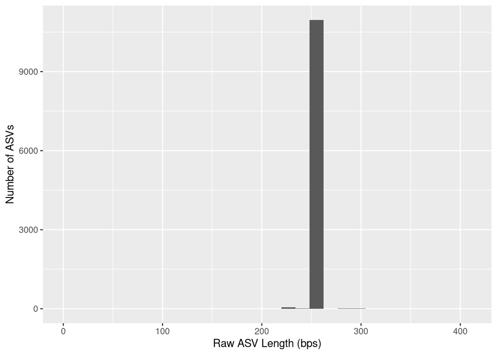

```r
# Inspect the distribution of sequence lengths of all ASVs in data set
plot_ASVLength_raw <-
  data.frame(Seq_Length = nchar(getSequences(raw_ASV_table))) %>%
  ggplot(aes(x = Seq_Length)) +
  geom_histogram() +
  # include the x-axis scales
  scale_x_continuous(limits = c(0, maxLength_ASV + 5)) +
  labs(y = "Number of ASVs", x = "Raw ASV Length (bps)")

# Show the plot
plot_ASVLength_raw
```

INTERPRETATION #2: The ASV length data largely matches my hypothesis from Interpretation 1, which predicted an expected ASV length of approximately 252 bp. The observed distribution shows a strong peak at 253 bp, with a smaller peak at 254 bp, which is very close to the expected value and within normal biological and sequencing variation. This indicates that the majority of ASVs were correctly reconstructed during merging. However, the presence of additional ASVs at shorter and longer lengths does not match the hypothesis and likely represents sequencing artifacts such as truncated reads, chimeras, or read-through into adapter sequences. Overall, the dominant peak supports the hypothesis, while the low-frequency off-target lengths indicate noise that should be removed.

INTERPRETATION #3: Based on the ASV length distribution, I will retain only sequences that match the dominant biological length of 253 bp and remove all other ASVs. The strong peak at 253 bp indicates that this is the correct reconstructed length of the V4 amplicon in this dataset, while the other lengths represent noise or artifacts. Keeping only the dominant length prevents misformed ASVs from affecting diversity estimates and taxonomic assignment. This filtering step improves the overall quality and reliability of the dataset.

# Trim ASV lengths

Now that we are convinced that the dominant biological ASV length in this dataset is 253 bp, we will trim the ASV table to retain only ASVs of that length. This removes lower-frequency off-target lengths that are likely artifacts.

```r
# Subset only ASVs that are 253 bp long
raw_ASV_table_trimmed <-
  raw_ASV_table[, nchar(colnames(raw_ASV_table)) == 253]

# Inspect the distribution of sequence lengths of all ASVs in dataset
table(nchar(getSequences(raw_ASV_table_trimmed)))
```

```
##
##  253
## 9240
```

```r
# What proportion of total ASV sequences are left in the data?
percRetained_Trimmed <- sum(raw_ASV_table_trimmed) / sum(raw_ASV_table)
percRetained_Trimmed
```

```
## [1] 0.9654684
```

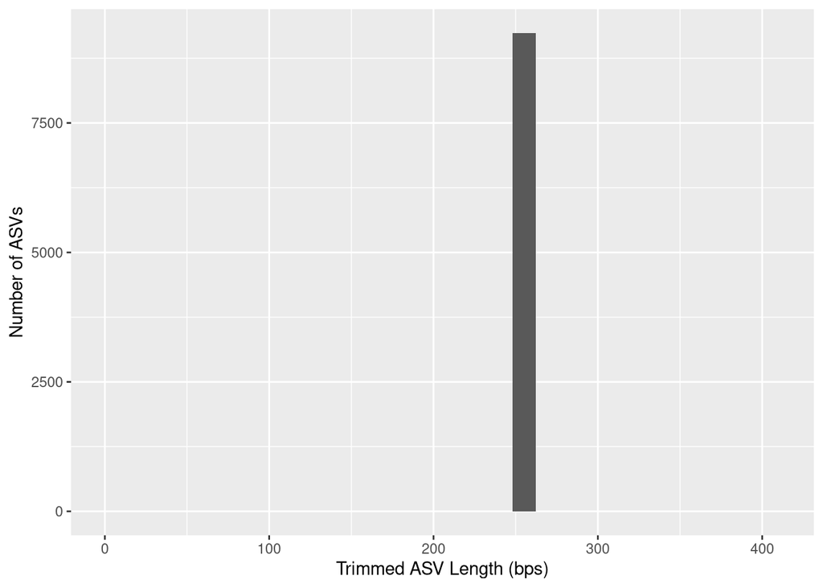

```r
# Inspect the distribution of sequence lengths of all ASVs in dataset
# AFTER TRIM
plot_ASVLength_trimmed <-
  data.frame(Seq_Length = nchar(getSequences(raw_ASV_table_trimmed))) %>%
  ggplot(aes(x = Seq_Length)) +
  geom_histogram() +
  scale_x_continuous(limits = c(0, maxLength_ASV + 5)) +
  labs(y = "Number of ASVs", x = "Trimmed ASV Length (bps)")

# Show the plot
plot_ASVLength_trimmed
```

# Remove Chimeras

Chimeras are artificial sequences formed during PCR when incomplete extension products prime different templates in later cycles. These do not represent real biological sequences and must be removed before downstream analysis.

```r
# Remove the chimeras in the trimmed ASV table
noChimeras_ASV_table <-
  removeBimeraDenovo(raw_ASV_table_trimmed,
                     method = "consensus",
                     multithread = n_threads,
                     verbose = TRUE)
```

```
## Identified 452 bimeras out of 9240 input sequences.
```

```r
# Check the dimensions
dim(noChimeras_ASV_table)
```

```
## [1]  117 8788
```

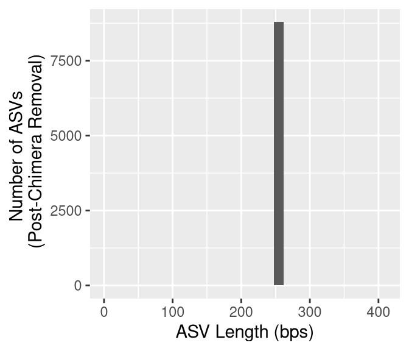

```r
# What proportion is left of the sequences?
# Chimera removal compared to trimming
percRetained_chimerasTrimmed <- sum(noChimeras_ASV_table) / sum(raw_ASV_table_trimmed)

# Chimera removal compared to raw
percRetained_chimerasRaw <- sum(noChimeras_ASV_table) / sum(raw_ASV_table)

# Plot it
plot_ASVLength_NoChimeras <-
  data.frame(Seq_Length_NoChim = nchar(getSequences(noChimeras_ASV_table))) %>%
  ggplot(aes(x = Seq_Length_NoChim)) +
  geom_histogram() +
  scale_x_continuous(limits = c(0, maxLength_ASV + 5)) +
  labs(y = "Number of ASVs \n (Post-Chimera Removal)",
       x = "ASV Length (bps)")

# Show the plot
plot_ASVLength_NoChimeras
```

INTERPRETATION #4: The proportion of raw ASVs retained after trimming was 0.965, indicating that the vast majority of sequences were at the expected biological length of 253 bp and that only a small amount of off-target noise was removed. After chimera removal, the proportion of trimmed ASVs retained was 0.986, showing that very few sequences were identified as chimeric. Overall, the proportion of total merged ASVs retained after both trimming and chimera removal was 0.952, meaning that most of the data was preserved through both steps. These results suggest that the ASV length trimming was appropriate, as it removed low-frequency artifacts while retaining the dominant biological signal and maintaining a high proportion of usable sequences.

### Plot ASV Lengths

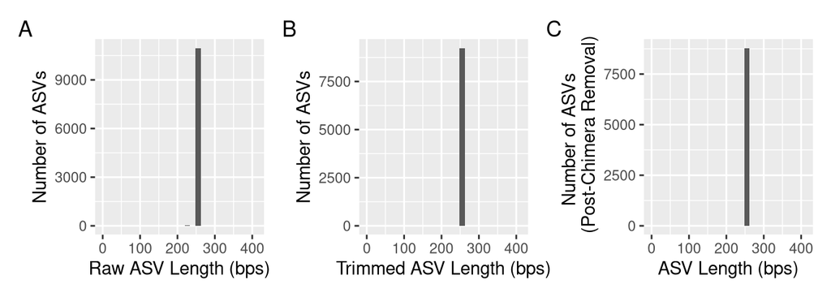

```r
plot_ASVLength_raw + plot_ASVLength_trimmed + plot_ASVLength_NoChimeras +
  plot_annotation(tag_levels = 'A')
```

# Assign Taxonomy

Now, we will assign taxonomy to our ASVs using the Silva reference database.

```r
# Assign taxonomy up to genus level
taxa_train <-
  assignTaxonomy(
    noChimeras_ASV_table,
    refFasta = "/local/workdir/in_class_data/taxonomy/silva_nr99_v138.2_toGenus_trainset.fa.gz",
    multithread = n_threads
  )

# Add species-level assignment
taxa_addSpecies <-
  addSpecies(
    taxa_train,
    refFasta = "/local/workdir/in_class_data/taxonomy/silva_v138.2_assignSpecies.fa.gz"
  )

# Inspect taxonomy
taxa_print <- taxa_addSpecies
rownames(taxa_print) <- NULL
head(taxa_print)
```

```
##      Kingdom    Phylum           Class                 Order
## [1,] "Bacteria" "Pseudomonadota" "Gammaproteobacteria" "Enterobacterales"
## [2,] "Bacteria" "Pseudomonadota" "Gammaproteobacteria" "Enterobacterales"
## [3,] "Bacteria" "Pseudomonadota" "Gammaproteobacteria" "Enterobacterales"
## [4,] "Bacteria" "Pseudomonadota" "Gammaproteobacteria" "Enterobacterales"
## [5,] "Bacteria" "Pseudomonadota" "Gammaproteobacteria" "Enterobacterales"
## [6,] "Bacteria" "Pseudomonadota" "Gammaproteobacteria" "Enterobacterales"
##      Family                   Genus               Species
## [1,] "Moritellaceae"          "Moritella"         NA
## [2,] "Vibrionaceae"           "Enterovibrio"      NA
## [3,] "Pseudoalteromonadaceae" "Pseudoalteromonas" NA
## [4,] "Vibrionaceae"           "Vibrio"            NA
## [5,] "Vibrionaceae"           "Aliivibrio"        NA
## [6,] "Vibrionaceae"           "Vibrio"            NA
```

# Track the read counts

Here, we will look at the number of reads that were lost in the filtering, denoising, merging, and chimera removal.

```r
# A little function to identify number seqs
getN <- function(x) sum(getUniques(x))

# Make the table to track the seqs
track <- cbind(
  sapply(dada_forward, getN),
  sapply(dada_reverse, getN),
  sapply(merged_ASVs, getN),
  rowSums(noChimeras_ASV_table)
)

# Update column names
colnames(track) <- c("denoisedF", "denoisedR", "merged", "nochim")
rownames(track) <- row.names(noChimeras_ASV_table)

# Generate a dataframe to track the reads through our DADA2 pipeline
track_counts_df <-
  track %>%
  as.data.frame() %>%
  rownames_to_column(var = "sample_names")

# Intuition check
stopifnot(track_counts_df$sample_names == row.names(noChimeras_ASV_table))

# Add a new column with the number of ASVs
track_counts_df <-
  track_counts_df %>%
  mutate(num_ASVs = rowSums(noChimeras_ASV_table > 1))

# Visualize it in table format
DT::datatable(track_counts_df)
```

|  | sample_names | denoisedF | denoisedR | merged | nochim | num_ASVs |
| --- | --- | --- | --- | --- | --- | --- |
| 1 | SRR8438042_R1_filtered.fastq.gz | 47605 | 47543 | 46569 | 44317 | 117 |
| 2 | SRR8438043_R1_filtered.fastq.gz | 4227 | 4208 | 4078 | 4038 | 15 |
| 3 | SRR8438044_R1_filtered.fastq.gz | 94929 | 94964 | 92568 | 89197 | 108 |
| 4 | SRR8438045_R1_filtered.fastq.gz | 20960 | 20915 | 19927 | 18695 | 79 |
| 5 | SRR8438046_R1_filtered.fastq.gz | 15402 | 15344 | 15079 | 14546 | 67 |
| 6 | SRR8438047_R1_filtered.fastq.gz | 26438 | 26453 | 26122 | 26042 | 62 |
| 7 | SRR8438048_R1_filtered.fastq.gz | 77805 | 77807 | 77302 | 76157 | 27 |
| 8 | SRR8438049_R1_filtered.fastq.gz | 108996 | 108942 | 107058 | 106071 | 117 |
| 9 | SRR8438050_R1_filtered.fastq.gz | 26755 | 26716 | 26212 | 26059 | 165 |
| 10 | SRR8438051_R1_filtered.fastq.gz | 82224 | 82178 | 79984 | 71380 | 14 |

[output cut: 107 more lines]

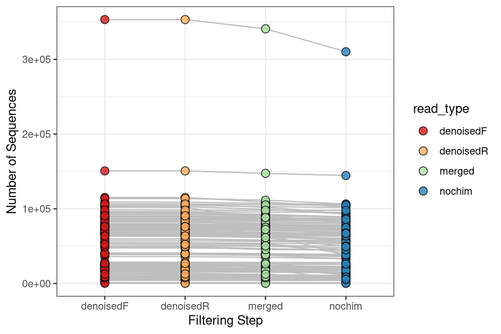

```r
# Plot it
track_counts_df %>%
  pivot_longer(denoisedF:nochim, names_to = "read_type", values_to = "num_reads") %>%
  mutate(read_type = fct_relevel(read_type, "denoisedF", "denoisedR", "merged", "nochim")) %>%
  ggplot(aes(x = read_type, y = num_reads, fill = read_type)) +
  geom_line(aes(group = sample_names), color = "grey") +
  geom_point(shape = 21, size = 3, alpha = 0.8) +
  scale_fill_brewer(palette = "Spectral") +
  labs(x = "Filtering Step", y = "Number of Sequences") +
  theme_bw()
```

# Plot read depth and ASV richness

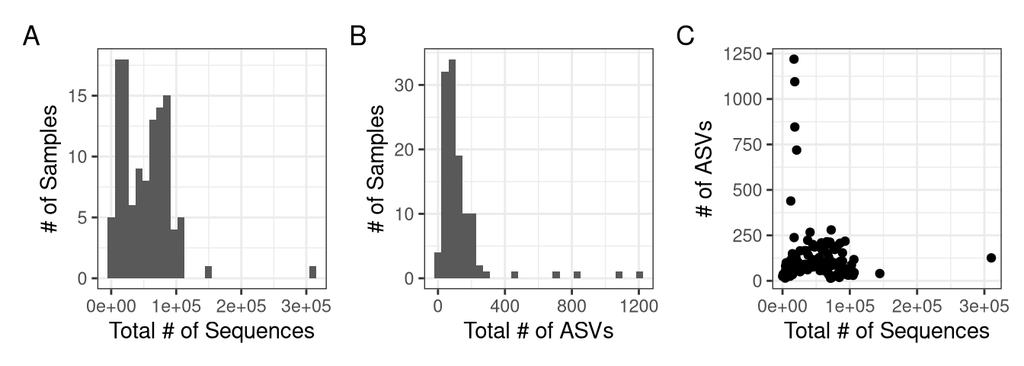

```r
plot_ReadDepth <-
  track_counts_df %>%
  ggplot(aes(x = nochim)) +
  geom_histogram() +
  labs(x = "Total # of Sequences", y = "# of Samples") +
  theme_bw()

plot_ASVRichness <-
  track_counts_df %>%
  ggplot(aes(x = num_ASVs)) +
  geom_histogram() +
  labs(x = "Total # of ASVs", y = "# of Samples") +
  theme_bw()

plot_ReadDepth_ASVRichness <-
  track_counts_df %>%
  ggplot(aes(x = nochim, y = num_ASVs)) +
  geom_point() +
  labs(x = "Total # of Sequences", y = "# of ASVs") +
  theme_bw()

plot_ReadDepth + plot_ASVRichness + plot_ReadDepth_ASVRichness +
  plot_annotation(tag_levels = 'A')
```

INTERPRETATION #5: Plot A shows that most samples have similar sequencing depth, generally clustering below ~100,000 reads, with a few samples having much higher read counts. This suggests overall consistent sequencing, but with some variability. There is an outlier of around 18-19 samples with frewer sequences, so this may suggest some grouped lesser associated taxa.

Plot B shows that most samples have relatively low to moderate ASV richness (most below ~300 ASVs), while a small number of samples have much higher richness, indicating potential outliers or samples with unusually high diversity.

```r
end_time <- Sys.time()
end_time
```

```
## [1] "2026-04-06 21:30:32 EDT"
```

```r
elapsed_time <- round((end_time - start_time), 3)
elapsed_time
```

```
## Time difference of 18.244 mins
```